# Ketten-Questionnaire

Christian ‘Becko’ Beck

21 Oktober 2016

## Import

Data had to be imported. The original xlsx was improved: two items (Person2 - Pompfe; 103 - best number of stones) were seperated into item groups, since multiple selections were effectively possible and encuraged by the questions. The file was exported into a csv for import into R (note: i know of the package ‘xlsx’, but it often does not what i want to do, while the other way through a csv has been profen to be rock solid)

```r
Testergebnis.Fragebogen <- read.csv2("~/ownCloud/Programming/jugger_data/chain2016/Testergebnis Fragebogen.csv", row.names=1, quote="'", stringsAsFactors=FALSE)

summary(Testergebnis.Fragebogen)
```

```
##     Person.1        Person.2            P2.Stab       P2.LP
##  Min.   : 0.000   Length:52          Min.   :1    Min.   :1
##  1st Qu.: 2.000   Class :character   1st Qu.:1    1st Qu.:1
##  Median : 3.000   Mode  :character   Median :1    Median :1
##  Mean   : 3.755                      Mean   :1    Mean   :1
##  3rd Qu.: 6.000                      3rd Qu.:1    3rd Qu.:1
##  Max.   :11.000                      Max.   :1    Max.   :1
##  NA's   :3                           NA's   :26   NA's   :45
##    P2.Schild       P2.Q       P2.Kette     P2.Quick       X10
##  Min.   :1    Min.   :1    Min.   :1    Min.   :1    Min.   :1.000
##  1st Qu.:1    1st Qu.:1    1st Qu.:1    1st Qu.:1    1st Qu.:4.000
##  Median :1    Median :1    Median :1    Median :1    Median :5.000
##  Mean   :1    Mean   :1    Mean   :1    Mean   :1    Mean   :4.373
##  3rd Qu.:1    3rd Qu.:1    3rd Qu.:1    3rd Qu.:1    3rd Qu.:5.000
##  Max.   :1    Max.   :1    Max.   :1    Max.   :1    Max.   :5.000
##  NA's   :43   NA's   :42   NA's   :37   NA's   :47   NA's   :1
##       X20             X30             X41             X42
##  Min.   :1.000   Min.   :1.000   Min.   :1.000   Min.   :1.000
##  1st Qu.:1.250   1st Qu.:1.000   1st Qu.:1.000   1st Qu.:1.000
##  Median :3.000   Median :2.000   Median :1.000   Median :1.000
##  Mean   :2.778   Mean   :2.364   Mean   :1.918   Mean   :1.885
##  3rd Qu.:3.750   3rd Qu.:3.000   3rd Qu.:3.000   3rd Qu.:3.000
##  Max.   :5.000   Max.   :5.000   Max.   :5.000   Max.   :5.000
##  NA's   :34      NA's   :8       NA's   :3
##       X43             X44             X45             X51
##  Min.   :1.000   Min.   :1.000   Min.   :1.000   Min.   :0.0000
##  1st Qu.:1.000   1st Qu.:1.000   1st Qu.:3.000   1st Qu.:0.0000
##  Median :2.000   Median :2.000   Median :4.000   Median :0.0000
##  Mean   :1.939   Mean   :1.837   Mean   :3.808   Mean   :0.2941
##  3rd Qu.:3.000   3rd Qu.:2.000   3rd Qu.:5.000   3rd Qu.:1.0000
##  Max.   :5.000   Max.   :4.000   Max.   :5.000   Max.   :1.0000
##  NA's   :3       NA's   :3                       NA's   :1
##       X52            X53             X54             X55
##  Min.   :0.00   Min.   :1.000   Min.   :1.000   Min.   :1.00
##  1st Qu.:0.00   1st Qu.:3.000   1st Qu.:1.000   1st Qu.:2.00
##  Median :0.00   Median :4.000   Median :2.000   Median :3.00
##  Mean   :0.69   Mean   :3.974   Mean   :1.927   Mean   :3.13
##  3rd Qu.:1.00   3rd Qu.:5.000   3rd Qu.:3.000   3rd Qu.:4.00
##  Max.   :6.00   Max.   :5.000   Max.   :4.000   Max.   :5.00
##  NA's   :2      NA's   :14      NA's   :11      NA's   :6
```

[output cut: 41 more lines]

```
##  Min.   :1.000   Min.   :1.000   Length:52          Min.   :1
##  1st Qu.:1.000   1st Qu.:3.000   Class :character   1st Qu.:1
##  Median :1.000   Median :4.000   Mode  :character   Median :1
##  Mean   :1.788   Mean   :3.519                      Mean   :1
##  3rd Qu.:2.250   3rd Qu.:5.000                      3rd Qu.:1
##  Max.   :5.000   Max.   :5.000                      Max.   :1
##                                                     NA's   :32
##      X103.6       X103.7       X103.8
##  Min.   :1    Min.   :1    Min.   :1
##  1st Qu.:1    1st Qu.:1    1st Qu.:1
##  Median :1    Median :1    Median :1
##  Mean   :1    Mean   :1    Mean   :1
##  3rd Qu.:1    3rd Qu.:1    3rd Qu.:1
##  Max.   :1    Max.   :1    Max.   :1
##  NA's   :38   NA's   :44   NA's   :35
```

## Cleaning

```r
library(magrittr)
library(dplyr)
##
## Attaching package: 'dplyr'
## Die folgenden Objekte sind maskiert von 'package:stats':
##
##     filter, lag
## Die folgenden Objekte sind maskiert von 'package:base':
##
##     intersect, setdiff, setequal, union

Testergebnis.Fragebogen %<>% select(-Person.2, -X103)
Testergebnis.Fragebogen$P2.Stab[is.na(Testergebnis.Fragebogen$P2.Stab)] <- 0
Testergebnis.Fragebogen$P2.LP[is.na(Testergebnis.Fragebogen$P2.LP)] <- 0
Testergebnis.Fragebogen$P2.Schild[is.na(Testergebnis.Fragebogen$P2.Schild)] <- 0
Testergebnis.Fragebogen$P2.Q[is.na(Testergebnis.Fragebogen$P2.Q)] <- 0
Testergebnis.Fragebogen$P2.Kette[is.na(Testergebnis.Fragebogen$P2.Kette)] <- 0
Testergebnis.Fragebogen$P2.Quick[is.na(Testergebnis.Fragebogen$P2.Quick)] <- 0

Testergebnis.Fragebogen$X103.5[is.na(Testergebnis.Fragebogen$X103.5)] <- 0
Testergebnis.Fragebogen$X103.6[is.na(Testergebnis.Fragebogen$X103.6)] <- 0
Testergebnis.Fragebogen$X103.7[is.na(Testergebnis.Fragebogen$X103.7)] <- 0
Testergebnis.Fragebogen$X103.8[is.na(Testergebnis.Fragebogen$X103.8)] <- 0

Testergebnis.Fragebogen %<>% mutate(P2.Stab = as.factor(P2.Stab), P2.LP = as.factor(P2.LP), P2.Schild = as.factor(P2.Schild), P2.Q = as.factor(P2.Q), P2.Quick = as.factor(P2.Quick), P2.Kette = as.factor(P2.Kette))
```

Note: There are a lot of questions that are asked wrong - the meaning of some of the answers is in many cases not clear. This is due to relative statements with no given baseline in the questions. Given the context and that the hypothesis to each statement is known (or guessable) beforehand makes it still possible - but quit dirty - to analyse all questions. However i issue a warning to not give these results to much credibility.

**Note on Q93:** Gerd already found that two outliers exist. Some more do exist and the downward outliers might be caused by reading/understanding the question wrong. I do not try to correct this (since i do not know the truth) and keep them in the data set. At a later point i might decide to drop them and will note this accordingly

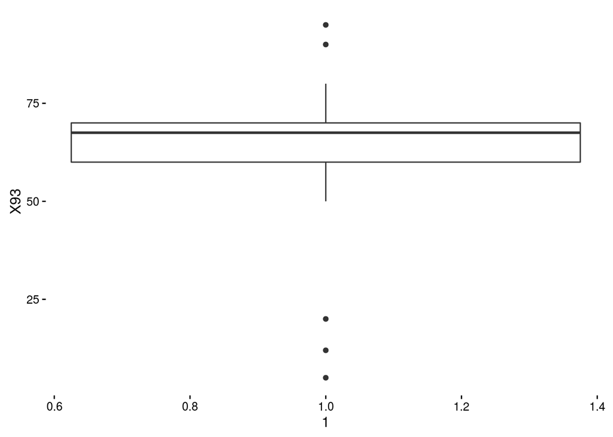

```r
library(dplyr)
library(ggplot2)

ggplot(Testergebnis.Fragebogen %>% select(X93) %>% filter(!is.na(X93))) + geom_boxplot(aes(x = 1, y = X93)) + theme_classic()
```

```r
# tX93 <- scale(Testergebnis.Fragebogen$X93)
# Testergebnis.Fragebogen$X93[abs(tX93) > 1.5] <- NA
```

## Basic Visualisation and exploration

Note: Question Person.2 (which is your MAIN Pompfe) is somewhat ill posed. However important in the current context is just the number of chain players, all others can be treated the same.

- Count of questionnaires: 52
- Count of chains: 15
- Ratio of chains: 0.2884615

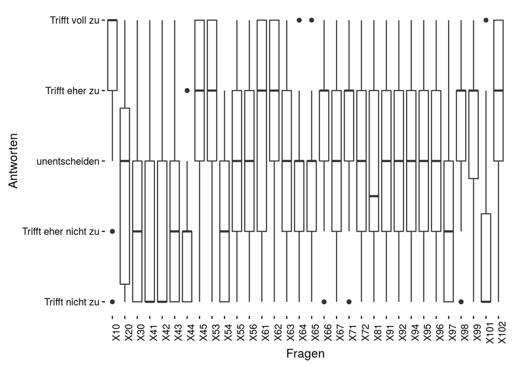

```r
library(ggplot2)
library(reshape2)
library(knitr)

# boxplot for each score
ggplot(melt(Testergebnis.Fragebogen %>% select(-Person.1, -P2.Q,-P2.Stab,-P2.LP,-P2.Schild,-P2.Quick, -P2.Kette, -X103.5,-X103.6,-X103.7,-X103.8, -X93, -X51,-X52))) +
  geom_boxplot(aes(x = variable, y = value)) +
  theme_classic() + theme(axis.text.x = element_text(angle = 90)) +
  scale_y_continuous(name = "Antworten", breaks = 1:5, minor_breaks = NULL, labels = c("Trifft nicht zu","Trifft eher nicht zu","unentscheiden","Trifft eher zu", "Trifft voll zu")) +
  scale_x_discrete(name = "Fragen")
```

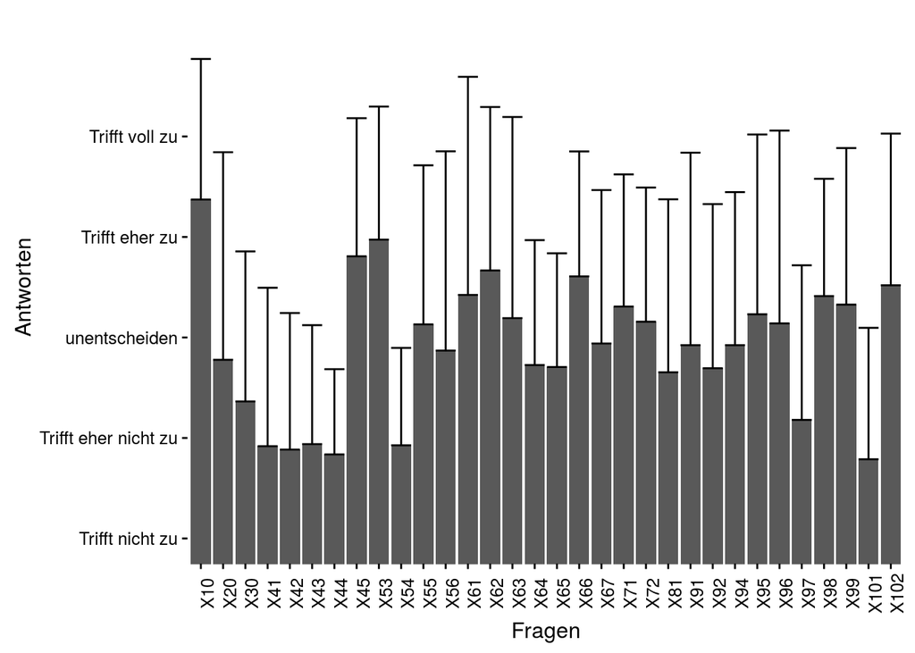

```r
# Aggregate of all scores
Testergebnis.stats <- Testergebnis.Fragebogen %>% select(-Person.1, -P2.Q,-P2.Stab,-P2.LP,-P2.Schild,-P2.Quick, -P2.Kette, -X103.5,-X103.6,-X103.7,-X103.8, -X93, -X51,-X52) %>% melt() %>% group_by(variable) %>% summarise(avg = mean(value, na.rm = TRUE), var = var(value, na.rm = TRUE))
ggplot(Testergebnis.stats) +
  geom_bar(aes(x = variable, y = avg),stat = "identity") +
  geom_errorbar(aes(x = variable, ymin = avg, ymax = avg+var)) +
  coord_cartesian(ylim = c(1,6)) +
  theme_classic() + theme(axis.text.x = element_text(angle = 90)) +
  scale_y_continuous(name = "Antworten", breaks = 1:5, minor_breaks = NULL, labels = c("Trifft nicht zu","Trifft eher nicht zu","unentscheiden","Trifft eher zu", "Trifft voll zu")) +
  scale_x_discrete(name = "Fragen")
```

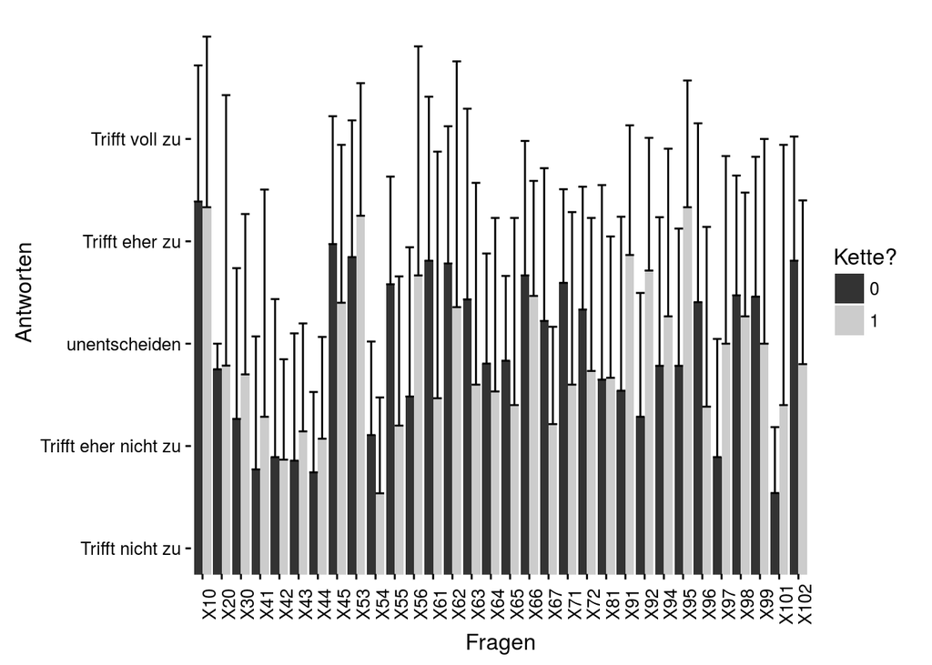

```r
# Aggregate of all scores nach Kette/nicht-Kette
Testergebnis.stats2 <- Testergebnis.Fragebogen %>% select(-Person.1, -P2.Q,-P2.Stab,-P2.LP,-P2.Schild,-P2.Quick, -X103.5,-X103.6,-X103.7,-X103.8, -X93, -X51,-X52) %>% melt(id.vars = "P2.Kette") %>% group_by(P2.Kette, variable) %>% summarise(avg = mean(value, na.rm = TRUE), var = var(value, na.rm = TRUE))
ggplot(Testergebnis.stats2) +
  geom_bar(aes(x = variable, y = avg, fill = P2.Kette),stat = "identity", position = "dodge") +
  geom_errorbar(aes(x = variable, ymin = avg, ymax = avg+var, fill = P2.Kette), position = "dodge", width = 0.9) +
  coord_cartesian(ylim = c(1,6)) +
  theme_classic() + theme(axis.text.x = element_text(angle = 90)) +
  scale_y_continuous(name = "Antworten", breaks = 1:5, minor_breaks = NULL, labels = c("Trifft nicht zu","Trifft eher nicht zu","unentscheiden","Trifft eher zu", "Trifft voll zu")) +
  scale_x_discrete(name = "Fragen") +
#  scale_fill_discrete(name = "Kette") +
  scale_fill_grey(name = "Kette?")
```

## First statistics

```r
chain.stats <- Testergebnis.Fragebogen %>% select(-Person.1, -P2.Q,-P2.Stab,-P2.LP,-P2.Schild,-P2.Quick, -P2.Kette, -X103.5,-X103.6,-X103.7,-X103.8, -X93, -X51,-X52)

##### normality
ntest <- data.frame(Question = colnames(chain.stats), W = NA, p = NA, "H0 rejected?" = NA, stringsAsFactors = FALSE)
for (ci in 1:ncol(chain.stats)) {
  st <- shapiro.test(x = chain.stats[,ci])
  ntest[ci,2] <- st$statistic
  ntest[ci,3] <- st$p.value
  ntest[ci,4] <- st$p.value < 0.05
}

kable(x = ntest, digits = 2,
      caption = "Results of the Shapiro-test for normality. TRUE means H0 was rejected at confidence level 0.05.")
```

Results of the Shapiro-test for normality. TRUE means H0 was rejected at confidence level 0.05.

| Question | W | p | H0.rejected. |
| --- | --- | --- | --- |
| X10 | 0.59 | 0.00 | TRUE |
| X20 | 0.88 | 0.03 | TRUE |
| X30 | 0.87 | 0.00 | TRUE |
| X41 | 0.72 | 0.00 | TRUE |
| X42 | 0.76 | 0.00 | TRUE |
| X43 | 0.80 | 0.00 | TRUE |
| X44 | 0.79 | 0.00 | TRUE |
| X45 | 0.85 | 0.00 | TRUE |
| X53 | 0.82 | 0.00 | TRUE |
| X54 | 0.82 | 0.00 | TRUE |
| X55 | 0.91 | 0.00 | TRUE |
| X56 | 0.89 | 0.00 | TRUE |
| X61 | 0.83 | 0.00 | TRUE |
| X62 | 0.84 | 0.00 | TRUE |
| X63 | 0.88 | 0.00 | TRUE |
| X64 | 0.90 | 0.00 | TRUE |
| X65 | 0.86 | 0.00 | TRUE |
| X66 | 0.86 | 0.00 | TRUE |
| X67 | 0.90 | 0.00 | TRUE |
| X71 | 0.89 | 0.00 | TRUE |
| X72 | 0.90 | 0.00 | TRUE |
| X81 | 0.89 | 0.00 | TRUE |
| X91 | 0.87 | 0.00 | TRUE |
| X92 | 0.90 | 0.00 | TRUE |
| X94 | 0.90 | 0.00 | TRUE |
| X95 | 0.89 | 0.00 | TRUE |
| X96 | 0.89 | 0.00 | TRUE |
| X97 | 0.83 | 0.00 | TRUE |
| X98 | 0.85 | 0.00 | TRUE |
| X99 | 0.89 | 0.00 | TRUE |
| X101 | 0.72 | 0.00 | TRUE |
| X102 | 0.89 | 0.00 | TRUE |

```r
###### H0 test
wtest <- data.frame(Question = colnames(chain.stats), V = NA, p = NA, "H0 rejected?" = NA, "H0 rejected? Boferroni" = NA, stringsAsFactors = FALSE)
for (ci in 1:ncol(chain.stats)) {
  wt <- wilcox.test(x = chain.stats[,ci], alternative = "two.sided", mu = 3)
  wtest[ci,2] <- wt$statistic
  wtest[ci,3] <- wt$p.value
  wtest[ci,4] <- wt$p.value < 0.05
  wtest[ci,5] <- wt$p.value < 0.05 / ncol(chain.stats)
}

kable(x = wtest, digits = 2,
      caption = "Results of the Wilcoxon signed rank test with continuity correction. TRUE means H0 was rejected at confidence level 0.05 - either without or with Bonferroni correction for multiple comparison.")
```

Results of the Wilcoxon signed rank test with continuity correction. TRUE means H0 was rejected at confidence level 0.05 - either without or with Bonferroni correction for multiple comparison.

| Question | V | p | H0.rejected. | H0.rejected..Boferroni |
| --- | --- | --- | --- | --- |
| X10 | 1137.5 | 0.00 | TRUE | TRUE |
| X20 | 30.5 | 0.51 | FALSE | FALSE |
| X30 | 99.0 | 0.00 | TRUE | FALSE |
| X41 | 55.0 | 0.00 | TRUE | TRUE |
| X42 | 89.0 | 0.00 | TRUE | TRUE |
| X43 | 44.5 | 0.00 | TRUE | TRUE |
| X44 | 48.0 | 0.00 | TRUE | TRUE |
| X45 | 643.5 | 0.00 | TRUE | TRUE |
| X53 | 437.0 | 0.00 | TRUE | TRUE |
| X54 | 22.5 | 0.00 | TRUE | TRUE |
| X55 | 264.5 | 0.50 | FALSE | FALSE |
| X56 | 296.0 | 0.55 | FALSE | FALSE |
| X61 | 760.0 | 0.07 | FALSE | FALSE |
| X62 | 755.0 | 0.00 | TRUE | FALSE |
| X63 | 488.0 | 0.45 | FALSE | FALSE |
| X64 | 149.5 | 0.08 | FALSE | FALSE |
| X65 | 88.0 | 0.04 | TRUE | FALSE |
| X66 | 705.0 | 0.00 | TRUE | TRUE |
| X67 | 252.5 | 0.61 | FALSE | FALSE |
| X71 | 508.5 | 0.08 | FALSE | FALSE |
| X72 | 428.5 | 0.38 | FALSE | FALSE |
| X81 | 281.0 | 0.07 | FALSE | FALSE |
| X91 | 442.5 | 0.53 | FALSE | FALSE |
| X92 | 256.0 | 0.09 | FALSE | FALSE |
| X94 | 409.5 | 0.59 | FALSE | FALSE |
| X95 | 487.5 | 0.29 | FALSE | FALSE |
| X96 | 472.5 | 0.58 | FALSE | FALSE |
| X97 | 93.0 | 0.00 | TRUE | TRUE |
| X98 | 580.0 | 0.02 | TRUE | FALSE |
| X99 | 531.0 | 0.09 | FALSE | FALSE |
| X101 | 74.0 | 0.00 | TRUE | TRUE |
| X102 | 616.0 | 0.00 | TRUE | FALSE |

**Note:** the above test confirm Gerds intuition on most of the questions and answers.

**Another note:** I hoped for the data to be such that i can highlight some possible p-Hacking in there to support an argument about statistics - how one can (intended or not) shift the results of an anlysis based on his or her prejudices. But “sadly” the data did not follow and so even with two-sided testing and quit conservative Bonferroni correction the pattern of significant answers emerges. (ps: I’m not t-testing here, because the data is not normal enough)

Next: group differences between chain and non-chain players!

```r
chain.stats <- Testergebnis.Fragebogen %>% select(-Person.1, -P2.Q,-P2.Stab,-P2.LP,-P2.Schild,-P2.Quick, -X103.5,-X103.6,-X103.7,-X103.8, -X93, -X51,-X52)

###### two-sample H0 test
twtest <- data.frame(Question = colnames(chain.stats)[-1], V = NA, p = NA, "H0 rejected?" = NA, "H0 rejected? Boferroni" = NA, stringsAsFactors = FALSE)
for (ci in 2:ncol(chain.stats)) {
  twt <- wilcox.test(x = chain.stats[chain.stats[,1] == 1,ci], y = chain.stats[chain.stats[,1] != 1,ci], alternative = "two.sided")
  twtest[ci-1,2] <- twt$statistic
  twtest[ci-1,3] <- twt$p.value
  twtest[ci-1,4] <- twt$p.value < 0.05
  twtest[ci-1,5] <- twt$p.value < 0.05 / ncol(chain.stats)
}

kable(x = twtest, digits = 2,
      caption = "Results of the two-sample Wilcoxon signed rank test with continuity correction - differences in ratings between chain players and non-chain players. TRUE means H0 was rejected at confidence level 0.05 - either without or with Bonferroni correction for multiple comparison.")
```

Results of the two-sample Wilcoxon signed rank test with continuity correction - differences in ratings between chain players and non-chain players. TRUE means H0 was rejected at confidence level 0.05 - either without or with Bonferroni correction for multiple comparison.

| Question | V | p | H0.rejected. | H0.rejected..Boferroni |
| --- | --- | --- | --- | --- |
| X10 | 270.0 | 1.00 | FALSE | FALSE |
| X20 | 28.0 | 1.00 | FALSE | FALSE |
| X30 | 205.5 | 0.31 | FALSE | FALSE |
| X41 | 294.5 | 0.21 | FALSE | FALSE |
| X42 | 291.5 | 0.77 | FALSE | FALSE |
| X43 | 289.0 | 0.30 | FALSE | FALSE |
| X44 | 294.0 | 0.25 | FALSE | FALSE |
| X45 | 205.5 | 0.13 | FALSE | FALSE |
| X53 | 191.5 | 0.25 | FALSE | FALSE |
| X54 | 116.5 | 0.05 | FALSE | FALSE |
| X55 | 88.5 | 0.00 | TRUE | TRUE |
| X56 | 340.5 | 0.01 | TRUE | FALSE |
| X61 | 152.5 | 0.01 | TRUE | FALSE |
| X62 | 224.0 | 0.45 | FALSE | FALSE |
| X63 | 185.5 | 0.06 | FALSE | FALSE |
| X64 | 216.5 | 0.25 | FALSE | FALSE |
| X65 | 216.5 | 0.24 | FALSE | FALSE |
| X66 | 239.5 | 0.51 | FALSE | FALSE |
| X67 | 130.0 | 0.01 | TRUE | FALSE |
| X71 | 152.5 | 0.01 | TRUE | FALSE |
| X72 | 192.0 | 0.10 | FALSE | FALSE |
| X81 | 284.5 | 0.89 | FALSE | FALSE |
| X91 | 431.0 | 0.00 | TRUE | TRUE |
| X92 | 399.0 | 0.00 | TRUE | TRUE |
| X94 | 339.5 | 0.20 | FALSE | FALSE |
| X95 | 473.5 | 0.00 | TRUE | TRUE |
| X96 | 141.0 | 0.02 | TRUE | FALSE |
| X97 | 349.5 | 0.01 | TRUE | FALSE |
| X98 | 240.0 | 0.51 | FALSE | FALSE |
| X99 | 225.5 | 0.28 | FALSE | FALSE |
| X101 | 356.5 | 0.07 | FALSE | FALSE |
| X102 | 150.0 | 0.01 | TRUE | FALSE |

Now it’s getting interesting (i report only Bonferroni corrected significance, since no hypothesis exists):

- On doubles chain players and non-chain players seem to disagree (Q55)
- The three questions about the value of chain specialities - such as hit-rate, reach and pin (Q91, Q92, Q95) - are seen differently by chains than by non-chains.

And now onto Gerds big news: **Question 103!** What number of stones is preferred? 5,6,7 or *more than 8*? (note that *more than 8* was recorded by some subjects as *8 or above*, nevertheless the answer options were erronouse and we can’t dismiss any effect of this on the results with absoulte certainty - even though it seems plausible)

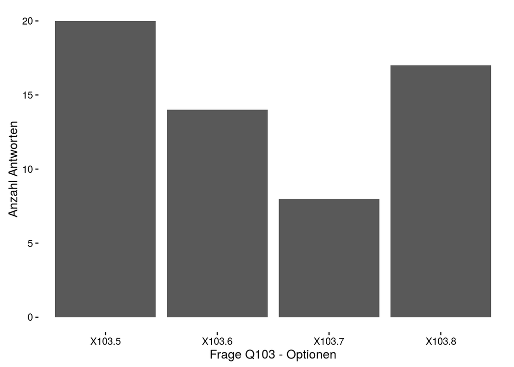

```r
library(reshape2)
X103.stats <- Testergebnis.Fragebogen %>% select(X103.5,X103.6,X103.7,X103.8) %>% summarise_all(funs(sum))

ggplot(melt(X103.stats)) +
  geom_bar(aes(x = variable, y = value), stat = "identity") +
  theme_classic() +
  scale_y_continuous(name = "Anzahl Antworten") +
  scale_x_discrete(name = "Frage Q103 - Optionen")
```

```r
# only consider answers for 5 and 8 (6 and 7 are noise to me, since no hypothesis nor test for those was present)
binom.test(x = c(X103.stats$X103.5[1], X103.stats$X103.8[1]), p = 0.5, alternative = "greater")
```

```
##
##  Exact binomial test
##
## data:  c(X103.stats$X103.5[1], X103.stats$X103.8[1])
## number of successes = 20, number of trials = 37, p-value = 0.3714
## alternative hypothesis: true probability of success is greater than 0.5
## 95 percent confidence interval:
##  0.3938002 1.0000000
## sample estimates:
## probability of success
##              0.5405405
```

```r
binom.test(x = X103.stats$X103.5[1], n = nrow(Testergebnis.Fragebogen), p = 0.5, alternative = "greater")
```

```
##
##  Exact binomial test
##
## data:  X103.stats$X103.5[1] and nrow(Testergebnis.Fragebogen)
## number of successes = 20, number of trials = 52, p-value = 0.9648
## alternative hypothesis: true probability of success is greater than 0.5
## 95 percent confidence interval:
##  0.2714462 1.0000000
## sample estimates:
## probability of success
##              0.3846154
```

As we can see, there is no significant trend towards one side or the other. Given that we have a very likely recruiters bias (among other methodlogical problems) i might add that the 8-to-5 ratio might be totally diffferent in the general population, as to 8 being the significant more prominent answer - this of course is speculative, but on the other side many of Gerds conclusions are speculative too.

## Relations

*Years of experience* against ratings and ratings against ratings:

```r
chain.stats <- Testergebnis.Fragebogen %>% select(-P2.Q,-P2.Stab,-P2.LP,-P2.Schild,-P2.Quick,-P2.Kette, -X103.5,-X103.6,-X103.7,-X103.8, -X51,-X52)

chain.stats.cor <- chain.stats %>% psych::corr.test(use = "pairwise", method = "pearson", adjust = "holm")
# note: holm multiple comparison correction is already applied here

kable(x = data.frame(Question = colnames(chain.stats.cor$r)[-1],
                     ChainR = chain.stats.cor$r[-1,"Person.1"],
                     ChainP = chain.stats.cor$p[-1,"Person.1"],
                     ChainPs = chain.stats.cor$p[-1,"Person.1"] < 0.05),
      digits = 2, caption = "Correlation results of years of experience (Person.1) with all other ratings")
```

Correlation results of years of experience (Person.1) with all other ratings

|  | Question | ChainR | ChainP | ChainPs |
| --- | --- | --- | --- | --- |
| X10 | X10 | 0.02 | 0.91 | FALSE |
| X20 | X20 | -0.25 | 0.33 | FALSE |
| X30 | X30 | -0.38 | 0.01 | TRUE |
| X41 | X41 | -0.19 | 0.21 | FALSE |
| X42 | X42 | -0.25 | 0.08 | FALSE |
| X43 | X43 | -0.35 | 0.02 | TRUE |
| X44 | X44 | -0.16 | 0.28 | FALSE |
| X45 | X45 | 0.06 | 0.67 | FALSE |
| X53 | X53 | 0.00 | 0.99 | FALSE |
| X54 | X54 | 0.02 | 0.91 | FALSE |
| X55 | X55 | 0.04 | 0.80 | FALSE |
| X56 | X56 | -0.15 | 0.34 | FALSE |
| X61 | X61 | -0.08 | 0.59 | FALSE |
| X62 | X62 | 0.10 | 0.50 | FALSE |
| X63 | X63 | 0.10 | 0.49 | FALSE |
| X64 | X64 | 0.03 | 0.83 | FALSE |
| X65 | X65 | 0.00 | 0.99 | FALSE |
| X66 | X66 | 0.07 | 0.64 | FALSE |
| X67 | X67 | -0.09 | 0.55 | FALSE |
| X71 | X71 | -0.14 | 0.32 | FALSE |
| X72 | X72 | -0.04 | 0.76 | FALSE |
| X81 | X81 | -0.17 | 0.25 | FALSE |
| X91 | X91 | -0.27 | 0.06 | FALSE |
| X92 | X92 | -0.23 | 0.13 | FALSE |
| X93 | X93 | -0.25 | 0.09 | FALSE |
| X94 | X94 | 0.04 | 0.77 | FALSE |
| X95 | X95 | -0.04 | 0.79 | FALSE |
| X96 | X96 | -0.14 | 0.34 | FALSE |
| X97 | X97 | 0.07 | 0.62 | FALSE |
| X98 | X98 | -0.39 | 0.01 | TRUE |
| X99 | X99 | 0.00 | 1.00 | FALSE |
| X101 | X101 | 0.11 | 0.46 | FALSE |
| X102 | X102 | -0.14 | 0.33 | FALSE |

Note on years: interesting relations of experience

- more experience, less important was the missing of tactical interactions with chains (Q30)
- more experience, less was the game perceived influence of the rule change (Q43)
- more experience, less faster/wilder/stressful (Q98)

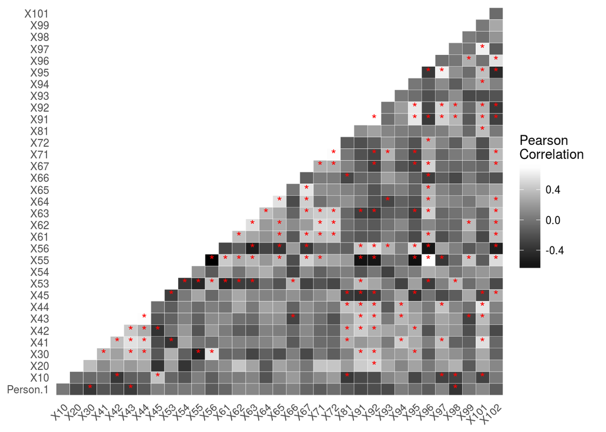

```r
library(reshape2)
library(ggplot2)

chain.stats.cor$r[upper.tri(chain.stats.cor$r, diag = TRUE)] <- NA
chain.stats.cor <- chain.stats.cor %$% inner_join(melt(r), melt(p), by = c("Var1" = "Var1", "Var2" = "Var2")) %>% rename(r = value.x, p = value.y) %>% filter(!is.na(r))

ggplot(chain.stats.cor, aes(Var1, Var2, fill = r)) + geom_tile(colour = "white") +
  geom_text(aes(Var1, Var2, label = ifelse(p < 0.05, "*", "")), color = "red", size = 4) +
  theme(axis.text.x = element_text(angle = 45, vjust = 1, hjust = 1), axis.title.x = element_blank(),
        axis.title.y = element_blank(), panel.grid.major = element_blank(), panel.border = element_blank(), panel.background = element_blank(), axis.ticks = element_blank()) +
  scale_fill_gradient(low = "black", high = "white", name = "Pearson\nCorrelation")
```

```r
# red dots mark significant correlations
```

It is a bit confusing - many variables (34 variables resulting in 561 unique correlations) and many significant correlations (147!). Lets try something else more visually convenient: Let’s treat the correlation matrix as a adjacency matrix (thresholded by p < 0.05)

Also note: The high number of significant correlations is a hint that the items are not meassuring independent components, but rather rely on a few latent dimensions. Lets test this first!

```r
chain.stats <- Testergebnis.Fragebogen %>% select(-Person.1, -P2.Q,-P2.Stab,-P2.LP,-P2.Schild,-P2.Quick,-P2.Kette, -X103.5,-X103.6,-X103.7,-X103.8, -X51,-X52)

factors <- prcomp(formula = ~ ., data = chain.stats, center = TRUE, scale = TRUE, retx = TRUE, na.action = na.omit)

kable(x = data.frame(PC = colnames(factors$rotation), Standard.deviations = round(factors$sdev,2)), digits = 2,
      caption = "Standard deviations of all primary components of the questionnaire data set.")
```

Standard deviations of all primary components of the questionnaire data set.

| PC | Standard.deviations |
| --- | --- |
| PC1 | 2.90 |
| PC2 | 2.76 |
| PC3 | 2.59 |
| PC4 | 2.06 |
| PC5 | 1.73 |
| PC6 | 1.56 |
| PC7 | 0.74 |
| PC8 | 0.00 |

```r
#kable(x = as.data.frame(factors$rotation), digits = 2,
#      caption = "Rotations matrix of the primary factor analysis. Shows decomposition of the factors into the set of asked questions.")
```

Only eight components are within this one data set and the last one is effectively zero, which reduces the number of componentes to 7. At first this seems like an interesting result, but hold on! How many rows of the result table are without any missing values? Exactly 8! Well that explains a lot … But lets have a look at the questions without answers: It turns out that question 20 askes only chain players (and thus 34 missing values), 30 asks only Pompfers (8 mising values - discrepancies with the numbers of the question Person2 are due to the fact that Person2 asks only for the main Pompfe, while Q20 and Q30 apply also for secondary and tertiary Pompfe), 53 and 54 are only applicable if a chain-double occured to that player (14 and 11 missing values). This is good news, since subjects read and followed the instructions :) So next take on primary components:

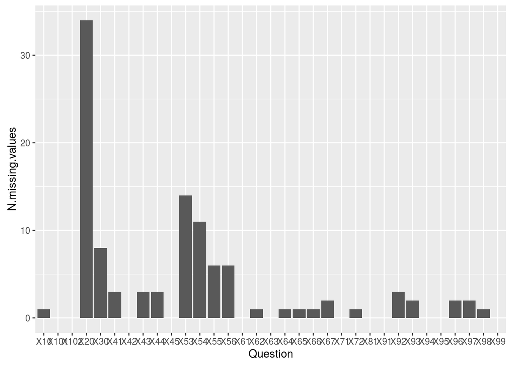

```r
library(ggplot2)
ggplot(data = data.frame(Question = colnames(chain.stats), N.missing.values = colSums(is.na(chain.stats))), aes(x = Question, y = N.missing.values)) + geom_bar(stat = "identity")
```

```r
chain.stats <- Testergebnis.Fragebogen %>% select(-Person.1, -P2.Q,-P2.Stab,-P2.LP,-P2.Schild,-P2.Quick,-P2.Kette, -X103.5,-X103.6,-X103.7,-X103.8, -X51,-X52, -X20, -X30, -X53, -X54)

factors <- prcomp(formula = ~ ., data = chain.stats, center = TRUE, scale = TRUE, retx = TRUE, na.action = na.omit)

kable(x = data.frame(PC = colnames(factors$rotation), Standard.deviations = round(factors$sdev,2)), digits = 2,
      caption = "Standard deviations of all primary components of the questionnaire data set.")
```

Standard deviations of all primary components of the questionnaire data set.

| PC | Standard.deviations |
| --- | --- |
| PC1 | 2.45 |
| PC2 | 2.26 |
| PC3 | 1.77 |
| PC4 | 1.45 |
| PC5 | 1.35 |
| PC6 | 1.31 |
| PC7 | 1.19 |
| PC8 | 1.09 |
| PC9 | 0.96 |
| PC10 | 0.93 |
| PC11 | 0.90 |
| PC12 | 0.86 |
| PC13 | 0.81 |
| PC14 | 0.69 |
| PC15 | 0.64 |
| PC16 | 0.60 |
| PC17 | 0.56 |
| PC18 | 0.49 |
| PC19 | 0.40 |
| PC20 | 0.35 |
| PC21 | 0.34 |
| PC22 | 0.30 |
| PC23 | 0.29 |
| PC24 | 0.27 |
| PC25 | 0.21 |
| PC26 | 0.19 |
| PC27 | 0.14 |
| PC28 | 0.11 |
| PC29 | 0.03 |

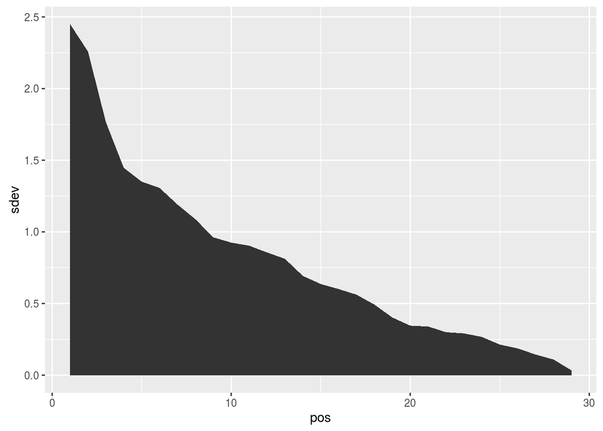

```r
ggplot(data = data.frame(pos = 1:length(colnames(factors$rotation)),PC = colnames(factors$rotation), sdev = factors$sdev), aes(x = pos, y = sdev)) + geom_area()
```

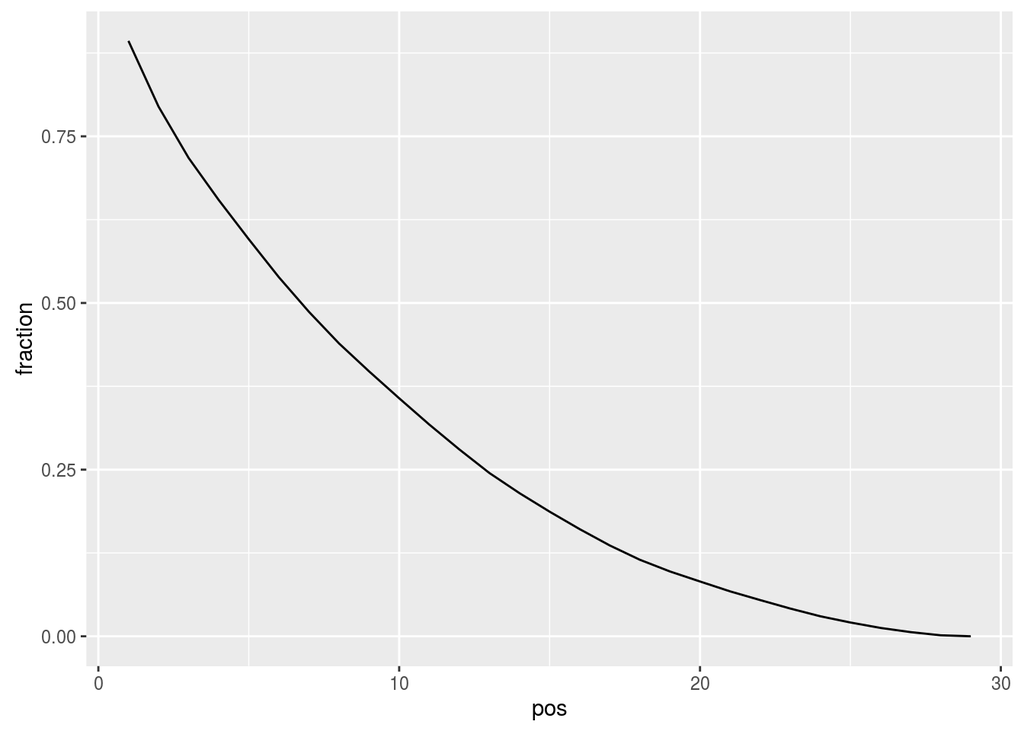

```r
ggplot(data = data.frame(pos = 1:length(colnames(factors$rotation)),PC = colnames(factors$rotation), fraction = 1 - cumsum(factors$sdev)/sum(factors$sdev)), aes(x = pos, y = fraction)) + geom_line() #+ geom_bar(stat = "identity")
```

```r
kable(x = as.data.frame(factors$rotation), digits = 2,
      caption = "Rotations matrix of the primary factor analysis. Shows decomposition of the factors into the set of asked questions.")
```

Rotations matrix of the primary factor analysis. Shows decomposition of the factors into the set of asked questions.

|  | PC1 | PC2 | PC3 | PC4 | PC5 | PC6 | PC7 | PC8 | PC9 | PC10 | PC11 | PC12 | PC13 | PC14 | PC15 | PC16 | PC17 | PC18 | PC19 | PC20 | PC21 | PC22 | PC23 | PC24 | PC25 | PC26 | PC27 | PC28 | PC29 |
| --- | --- | --- | --- | --- | --- | --- | --- | --- | --- | --- | --- | --- | --- | --- | --- | --- | --- | --- | --- | --- | --- | --- | --- | --- | --- | --- | --- | --- | --- |
| X10 | 0.06 | -0.25 | 0.34 | 0.00 | 0.06 | -0.22 | 0.14 | -0.26 | 0.07 | 0.13 | -0.13 | -0.09 | 0.10 | 0.03 | 0.00 | 0.24 | -0.21 | -0.12 | 0.30 | 0.04 | 0.20 | -0.18 | -0.07 | -0.01 | -0.15 | -0.14 | 0.45 | 0.28 | 0.11 |
| X41 | -0.05 | 0.25 | 0.23 | -0.20 | 0.25 | -0.09 | -0.24 | -0.13 | -0.04 | -0.08 | -0.19 | -0.16 | 0.02 | -0.24 | 0.12 | 0.08 | -0.40 | 0.38 | 0.18 | 0.18 | -0.07 | -0.01 | 0.06 | -0.24 | 0.08 | 0.01 | -0.19 | -0.20 | -0.18 |
| X42 | -0.10 | 0.23 | 0.13 | 0.23 | 0.05 | -0.13 | -0.15 | 0.01 | -0.05 | 0.40 | -0.03 | 0.14 | 0.59 | -0.11 | 0.13 | -0.27 | 0.18 | -0.01 | -0.03 | 0.06 | 0.06 | 0.26 | -0.09 | 0.00 | -0.03 | -0.09 | 0.18 | -0.17 | 0.01 |
| X43 | -0.09 | 0.31 | 0.16 | 0.09 | 0.19 | -0.19 | 0.15 | -0.02 | -0.04 | -0.29 | -0.06 | 0.20 | -0.20 | -0.10 | 0.24 | 0.09 | 0.07 | -0.33 | 0.06 | -0.03 | -0.13 | 0.05 | 0.05 | 0.33 | 0.39 | -0.33 | 0.06 | -0.06 | 0.00 |
| X44 | -0.11 | 0.30 | 0.23 | -0.09 | 0.14 | 0.03 | 0.17 | 0.12 | -0.04 | -0.12 | 0.18 | 0.06 | -0.15 | 0.29 | 0.14 | -0.29 | -0.19 | -0.23 | 0.08 | -0.01 | 0.40 | 0.12 | 0.14 | -0.11 | -0.26 | 0.35 | 0.02 | -0.07 | 0.11 |
| X45 | 0.16 | -0.23 | 0.14 | -0.14 | 0.07 | -0.11 | 0.29 | 0.30 | -0.33 | 0.08 | -0.04 | -0.25 | 0.03 | 0.27 | -0.04 | -0.03 | -0.09 | -0.20 | -0.13 | 0.21 | -0.32 | 0.29 | -0.02 | -0.20 | 0.00 | -0.18 | 0.03 | -0.11 | -0.25 |
| X55 | 0.34 | 0.10 | -0.10 | -0.07 | 0.21 | -0.04 | 0.05 | -0.10 | 0.18 | 0.08 | 0.05 | -0.11 | -0.01 | 0.23 | 0.09 | -0.08 | 0.00 | 0.03 | 0.27 | 0.06 | -0.30 | -0.02 | -0.49 | 0.35 | -0.17 | 0.12 | -0.16 | -0.18 | 0.23 |
| X56 | -0.27 | -0.12 | 0.14 | 0.07 | -0.08 | 0.05 | 0.16 | 0.13 | -0.28 | 0.15 | 0.13 | 0.01 | -0.39 | -0.45 | 0.15 | -0.10 | -0.01 | 0.18 | -0.03 | 0.10 | 0.04 | 0.07 | -0.36 | 0.04 | -0.27 | -0.17 | -0.08 | 0.05 | 0.21 |
| X61 | 0.24 | 0.13 | 0.14 | 0.01 | -0.01 | -0.05 | 0.24 | -0.45 | -0.17 | -0.16 | -0.04 | 0.06 | -0.02 | -0.02 | -0.39 | -0.29 | 0.09 | 0.17 | -0.34 | 0.33 | 0.02 | -0.06 | 0.02 | -0.03 | 0.13 | 0.02 | 0.06 | 0.01 | 0.25 |
| X62 | 0.17 | 0.10 | 0.26 | -0.18 | -0.16 | 0.29 | 0.12 | 0.11 | 0.04 | -0.30 | 0.12 | -0.33 | 0.12 | -0.12 | 0.05 | -0.12 | 0.33 | 0.26 | 0.25 | -0.21 | 0.06 | 0.21 | -0.11 | 0.04 | 0.16 | 0.02 | 0.22 | 0.17 | -0.14 |
| X63 | 0.25 | 0.14 | 0.07 | 0.03 | -0.23 | 0.16 | -0.25 | 0.06 | -0.18 | -0.24 | -0.10 | -0.18 | 0.16 | 0.01 | 0.33 | 0.38 | 0.12 | -0.19 | -0.20 | 0.27 | 0.11 | -0.05 | 0.02 | -0.05 | -0.21 | -0.07 | -0.10 | -0.04 | 0.34 |
| X64 | 0.10 | 0.23 | -0.19 | -0.07 | -0.28 | -0.24 | 0.05 | 0.27 | -0.38 | 0.14 | 0.04 | 0.08 | -0.04 | -0.13 | -0.19 | 0.23 | -0.08 | 0.05 | 0.26 | 0.00 | -0.05 | -0.06 | -0.01 | 0.01 | 0.23 | 0.37 | 0.30 | -0.14 | 0.18 |
| X65 | 0.13 | 0.16 | 0.12 | -0.07 | -0.27 | -0.45 | 0.04 | 0.06 | 0.34 | -0.08 | 0.00 | -0.13 | -0.02 | -0.21 | -0.33 | 0.09 | -0.09 | -0.09 | -0.15 | -0.30 | 0.08 | 0.27 | 0.00 | 0.01 | -0.26 | -0.15 | -0.18 | -0.14 | 0.03 |
| X66 | 0.00 | -0.24 | 0.26 | -0.15 | -0.19 | 0.01 | -0.08 | 0.19 | 0.48 | 0.00 | 0.07 | 0.31 | -0.08 | 0.06 | 0.19 | -0.01 | -0.12 | 0.12 | -0.14 | 0.19 | -0.18 | 0.17 | -0.03 | -0.16 | 0.28 | 0.10 | 0.16 | -0.08 | 0.31 |
| X67 | 0.19 | 0.23 | 0.06 | 0.13 | -0.20 | -0.30 | -0.05 | 0.08 | 0.01 | 0.08 | 0.39 | -0.09 | -0.03 | 0.10 | 0.29 | -0.22 | -0.12 | 0.09 | -0.19 | -0.08 | -0.16 | -0.47 | -0.04 | -0.14 | 0.03 | -0.11 | 0.03 | 0.25 | -0.18 |
| X71 | 0.15 | 0.11 | 0.31 | 0.28 | -0.04 | 0.35 | -0.10 | 0.07 | 0.12 | -0.01 | 0.01 | 0.18 | -0.12 | -0.20 | -0.23 | 0.08 | -0.08 | -0.18 | -0.07 | 0.14 | -0.22 | -0.14 | -0.06 | 0.14 | -0.25 | 0.19 | 0.22 | -0.15 | -0.41 |
| X72 | 0.16 | -0.01 | 0.29 | 0.09 | -0.23 | 0.34 | -0.05 | -0.20 | -0.25 | 0.28 | 0.11 | 0.09 | 0.03 | 0.16 | -0.05 | 0.07 | -0.36 | -0.04 | 0.05 | -0.36 | 0.03 | 0.13 | 0.01 | 0.12 | 0.25 | -0.12 | -0.30 | 0.00 | 0.10 |
| X81 | -0.02 | 0.22 | -0.13 | 0.20 | 0.37 | 0.23 | 0.02 | 0.12 | 0.17 | 0.16 | 0.33 | -0.32 | -0.02 | -0.12 | -0.19 | 0.13 | -0.13 | -0.01 | -0.03 | 0.03 | -0.20 | 0.14 | 0.28 | -0.09 | 0.02 | -0.14 | 0.16 | 0.18 | 0.35 |
| X91 | -0.27 | 0.17 | 0.09 | 0.07 | -0.26 | -0.01 | 0.24 | 0.05 | 0.12 | -0.02 | 0.17 | 0.17 | 0.21 | 0.17 | -0.18 | 0.18 | 0.10 | 0.07 | 0.35 | 0.42 | -0.09 | 0.00 | 0.06 | -0.01 | -0.06 | -0.08 | -0.38 | 0.24 | -0.08 |
| X92 | -0.30 | 0.10 | 0.11 | 0.04 | 0.05 | 0.05 | 0.33 | -0.27 | -0.01 | -0.03 | 0.10 | 0.01 | 0.08 | 0.12 | 0.09 | 0.37 | 0.21 | 0.08 | -0.17 | -0.34 | -0.24 | -0.12 | -0.15 | -0.35 | -0.08 | 0.13 | 0.06 | -0.30 | 0.05 |
| X93 | 0.02 | -0.08 | 0.27 | 0.42 | -0.01 | -0.14 | -0.03 | 0.05 | 0.12 | 0.28 | -0.18 | -0.37 | -0.32 | 0.10 | 0.01 | 0.00 | 0.35 | 0.02 | 0.11 | 0.09 | 0.15 | -0.08 | 0.14 | -0.05 | 0.23 | 0.18 | -0.18 | -0.17 | 0.02 |
| X94 | 0.02 | 0.03 | 0.36 | -0.25 | 0.32 | -0.08 | 0.00 | 0.34 | -0.11 | 0.14 | -0.19 | 0.17 | 0.11 | 0.03 | -0.09 | 0.12 | 0.19 | 0.20 | -0.23 | -0.19 | -0.11 | -0.20 | 0.16 | 0.26 | -0.11 | 0.15 | -0.16 | 0.28 | 0.12 |
| X95 | -0.32 | 0.08 | 0.04 | -0.12 | -0.21 | 0.02 | -0.07 | -0.18 | 0.02 | 0.04 | -0.27 | -0.28 | 0.05 | -0.15 | 0.04 | -0.21 | -0.08 | -0.40 | -0.05 | -0.03 | -0.38 | 0.04 | -0.07 | 0.00 | 0.06 | 0.35 | -0.07 | 0.34 | 0.09 |
| X96 | 0.26 | 0.21 | -0.13 | -0.04 | 0.00 | -0.06 | 0.02 | -0.27 | 0.01 | 0.27 | -0.07 | 0.20 | -0.31 | 0.04 | 0.25 | 0.22 | 0.15 | 0.12 | -0.07 | 0.04 | -0.03 | 0.45 | 0.09 | -0.08 | -0.12 | 0.14 | 0.06 | 0.34 | -0.22 |
| X97 | -0.23 | 0.19 | 0.03 | -0.18 | -0.26 | 0.08 | -0.24 | -0.05 | -0.05 | 0.09 | -0.19 | -0.05 | -0.25 | 0.36 | -0.09 | -0.15 | 0.10 | 0.18 | 0.10 | -0.04 | -0.21 | -0.05 | 0.23 | 0.12 | -0.25 | -0.35 | 0.28 | -0.16 | 0.09 |
| X98 | -0.08 | 0.15 | -0.17 | 0.25 | -0.15 | 0.12 | 0.43 | 0.17 | 0.15 | -0.01 | -0.40 | -0.15 | 0.11 | 0.12 | 0.17 | 0.04 | -0.35 | 0.30 | -0.25 | 0.02 | 0.12 | 0.01 | -0.03 | 0.27 | 0.02 | 0.03 | 0.09 | 0.02 | -0.05 |
| X99 | 0.13 | 0.00 | -0.05 | -0.44 | -0.12 | 0.16 | 0.35 | -0.10 | 0.15 | 0.36 | 0.08 | -0.06 | 0.05 | -0.30 | 0.20 | -0.05 | 0.08 | -0.16 | 0.01 | 0.11 | 0.05 | -0.23 | 0.35 | 0.12 | -0.01 | -0.06 | -0.06 | -0.26 | -0.05 |
| X101 | -0.15 | 0.28 | -0.01 | -0.33 | 0.06 | 0.12 | -0.13 | 0.08 | 0.12 | 0.25 | 0.01 | -0.11 | -0.11 | 0.15 | -0.21 | 0.17 | 0.04 | -0.14 | -0.24 | 0.14 | 0.33 | -0.08 | -0.48 | -0.04 | 0.26 | -0.13 | 0.05 | 0.06 | -0.14 |
| X102 | 0.25 | 0.18 | -0.08 | 0.06 | 0.03 | 0.19 | 0.16 | 0.20 | 0.09 | 0.05 | -0.44 | 0.24 | -0.06 | -0.09 | -0.06 | -0.18 | 0.05 | -0.13 | 0.22 | -0.16 | -0.04 | -0.16 | -0.11 | -0.51 | -0.02 | -0.22 | -0.09 | 0.09 | 0.14 |

So much for that. Now back to the graph analysis. As a reminder: I wanted to highlight some structures of the correelation matrix.

```r
library(visNetwork)

chain.stats.cor.nw <- chain.stats.cor %>% filter(Var1 != "Person.1", Var2 != "Person.1", p < 0.05)

cv <- chain.stats.cor.nw %$% visNetwork(nodes = data.frame(id = unique(chain.stats.cor$Var1),
                                                           label = unique(chain.stats.cor$Var1),
                                                           title = paste("<b>Question", unique(chain.stats.cor$Var1), "</b></br>",
                                                                         "Fill in question texts later")),
                 edges = data.frame(to = Var1, from = Var2,
                                    title = paste("<b>",Var1,"~",Var2,"</b></br>", "r =",  r),
                                    value = abs(r))) %>%
  visOptions(highlightNearest = TRUE, nodesIdSelection = TRUE)

cv
```

[interactive chart not shown]

Still a lot to digest within one picture - a dense strongly interconnected graph. But look: It’s interactive!!! This neat feature allows you to explore the structure by hand. Just hover, click, drag and drop.

However i still have the feeling that this visualisation doesn’t tell me everything - still it gives me a very good intuition of whats going on. So lets drill in with some graph methods.

```r
library(igraph) # just for the convenient implementation of largest.clique
cvig <- chain.stats.cor.nw %$% graph.data.frame(data.frame(to = Var1, from = Var2), directed = FALSE)
largest.cliques(cvig)
```

```
## [[1]]
## + 7/33 vertices, named:
## [1] X96  X55  X56  X63  X67  X95  X102
##
## [[2]]
## + 7/33 vertices, named:
## [1] X96  X55  X56  X63  X91  X95  X102
##
## [[3]]
## + 7/33 vertices, named:
## [1] X92  X71  X55  X95  X102 X63  X67
##
## [[4]]
## + 7/33 vertices, named:
## [1] X92  X67  X55  X56  X95  X102 X63
##
## [[5]]
## + 7/33 vertices, named:
## [1] X92  X91  X95  X55  X56  X102 X63
```

So it seems that there are five cliques of size seven. But those cliques are comprised of only only 10 nodes (Q95, Q96, Q56, Q63, Q55, Q102, Q91, Q92, Q71, Q67) and 4 of them contained within all cliques (Q55, Q63, Q95, Q102). An surprisingly there is a huge overlap between those nodes and the questions forming the first principal component of the above factor analysis. Let’s do one last statistic to finish this topic.

```r
# note: im not importing psych here, since the select of psych overwrites the select of dplyr
psych::alpha(chain.stats %>% select(X55,X63,X95,X102))
```

```
## Some items ( X95 ) were negatively correlated with the total scale and
## probably should be reversed.
## To do this, run the function again with the 'check.keys=TRUE' option
```

```
##
## Reliability analysis
## Call: psych::alpha(x = chain.stats %>% select(X55, X63, X95, X102))
##
##   raw_alpha std.alpha G6(smc) average_r    S/N  ase mean   sd
##      -0.11    -0.077    0.32    -0.018 -0.071 0.22  3.3 0.62
##
##  lower alpha upper     95% confidence boundaries
## -0.55 -0.11 0.33
##
##  Reliability if an item is dropped:
##      raw_alpha std.alpha G6(smc) average_r   S/N alpha se
## X55      -0.54     -0.54  -0.038     -0.13 -0.35    0.361
## X63      -0.92     -0.79   0.077     -0.17 -0.44    0.454
## X95       0.69      0.70   0.619      0.43  2.31    0.075
## X102     -0.98     -1.02  -0.152     -0.20 -0.50    0.451
##
##  Item statistics
##       n raw.r std.r r.cor r.drop mean  sd
## X55  46  0.62  0.66  0.69   0.18  3.1 1.3
## X63  52  0.76  0.72  0.55   0.27  3.2 1.4
## X95  52 -0.16 -0.21 -0.91  -0.59  3.2 1.3
## X102 52  0.72  0.77  0.78   0.36  3.5 1.2
##
## Non missing response frequency for each item
##         1    2    3    4    5 miss
## X55  0.13 0.15 0.35 0.20 0.17 0.12
## X63  0.19 0.12 0.21 0.27 0.21 0.00
## X95  0.15 0.13 0.23 0.29 0.19 0.00
## X102 0.06 0.17 0.23 0.27 0.27 0.00
```

```r
psych::alpha(chain.stats %>% select(X55,X63,X95,X102,X96,X56,X91,X92,X71,X67))
```

```
## Some items ( X95 X56 X91 X92 ) were negatively correlated with the total scale and
## probably should be reversed.
## To do this, run the function again with the 'check.keys=TRUE' option
```

```
##
## Reliability analysis
## Call: psych::alpha(x = chain.stats %>% select(X55, X63, X95, X102,
##     X96, X56, X91, X92, X71, X67))
##
##   raw_alpha std.alpha G6(smc) average_r  S/N  ase mean   sd
##      0.064       0.1    0.64     0.011 0.11 0.21  3.1 0.43
##
##  lower alpha upper     95% confidence boundaries
## -0.34 0.06 0.47
##
##  Reliability if an item is dropped:
##      raw_alpha std.alpha G6(smc) average_r      S/N alpha se
## X55      0.112   0.13104    0.59   1.6e-02  0.15080     0.20
## X63     -0.027  -0.00553    0.56  -6.1e-04 -0.00550     0.23
## X95      0.186   0.23585    0.69   3.3e-02  0.30865     0.17
## X102    -0.024  -0.00043    0.61  -4.7e-05 -0.00043     0.23
## X96     -0.145  -0.11342    0.52  -1.1e-02 -0.10187     0.26
## X56      0.310   0.32468    0.68   5.1e-02  0.48078     0.15
## X91      0.101   0.14878    0.62   1.9e-02  0.17478     0.18
## X92      0.109   0.17578    0.64   2.3e-02  0.21326     0.18
## X71     -0.103  -0.08194    0.55  -8.5e-03 -0.07574     0.25
## X67     -0.125  -0.09492    0.58  -9.7e-03 -0.08669     0.25
##
##  Item statistics
##       n raw.r  std.r  r.cor r.drop mean  sd
## X55  46  0.23  0.275  0.269 -0.064  3.1 1.3
## X63  52  0.45  0.460  0.420  0.129  3.2 1.4
## X95  52  0.15  0.094 -0.063 -0.175  3.2 1.3
## X102 52  0.41  0.454  0.373  0.143  3.5 1.2
## X96  50  0.58  0.578  0.606  0.275  3.1 1.4
## X56  46 -0.05 -0.097 -0.228 -0.367  2.9 1.4
## X91  52  0.28  0.247  0.184 -0.040  2.9 1.4
## X92  49  0.26  0.202  0.130 -0.057  2.7 1.3
## X71  52  0.50  0.546  0.486  0.272  3.3 1.1
## X67  50  0.53  0.559  0.484  0.282  2.9 1.2
##
## Non missing response frequency for each item
##         1    2    3    4    5 miss
## X55  0.13 0.15 0.35 0.20 0.17 0.12
## X63  0.19 0.12 0.21 0.27 0.21 0.00
## X95  0.15 0.13 0.23 0.29 0.19 0.00
## X102 0.06 0.17 0.23 0.27 0.27 0.00
## X96  0.18 0.16 0.18 0.30 0.18 0.04
## X56  0.22 0.22 0.22 0.17 0.17 0.12
## X91  0.23 0.17 0.15 0.33 0.12 0.00
## X92  0.22 0.24 0.22 0.22 0.08 0.06
## X71  0.10 0.13 0.25 0.40 0.12 0.00
## X67  0.18 0.14 0.34 0.24 0.10 0.04
```